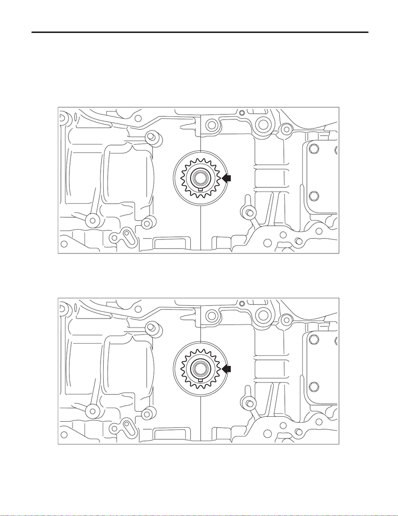

Crank Sprocket

MECHANICAL

17.Crank Sprocket

A: REMOVAL

NOTE:

When replacing a single part, perform the work with the engine assembly installed to body.

1) Remove the chain cover. <Ref. to ME(w/o STI)-93, REMOVAL, Chain Cover.>

2) Remove the timing chain. <Ref. to ME(w/o STI)-116, REMOVAL, Timing Chain Assembly.>

3) Remove the crank sprocket.

B: INSTALLATION

1) Install the crank sprocket.

NOTE:

The direction of installation is not specified for the crank sprocket.

2) Install the timing chain. <Ref. to ME(w/o STI)-124, INSTALLATION, Timing Chain Assembly.>

3) Install the chain cover. <Ref. to ME(w/o STI)-101, INSTALLATION, Chain Cover.>

[figure not shown]

Crank Sprocket

MECHANICAL

C: INSPECTION

1) Check the crank sprocket teeth for abnormal wear and scratches.

2) Make sure there is no free play between crank sprocket and key.